# CW_2 GY7702 R for Data Science

Student Number: 219031729

1/5/2022

# GY7702 R for Data Science Course Work 2

```r
library(dplyr)
library(tidyverse)
library(knitr)
library(readr)
library(lubridate)
library(ggplot2)
library(psych)
library(Hmisc)
library(corrplot)
library(PerformanceAnalytics)
library(car)
library(magrittr)
library(lmtest)
```

### 1.0 Loading and selecting data needed for analysis

Note: The variables for this analysis are encoded, see appendix 2 for full description of the variables.

```r
#Loading in data for analysis
OAC_Raw_uVariables_2011 <-
  read.csv("/home/kal41/Practical_204/CW1/GY7702_2021-22_Assignment_2_v1-1_datapack/2011_OAC_Raw_uVariables-GY7702_2021-22_CW2.csv")


#Loading data that would be used to extract my Output Area
LAD_Allocation_data <- read.csv("/home/kal41/Practical_204/CW1/GY7702_2021-22_Assignment_2_v1-1_datapack/new.csv")

#Filtering out my allocated LAD
LAD_Allocation_data <- LAD_Allocation_data %>%
  filter(LAD11CD == "E09000006")

#Joining the two data to select my allocated Output Area only
OwnLadd <- LAD_Allocation_data   %>%
  left_join(
    OAC_Raw_uVariables_2011,  by = c("OA11CD" = "OA")
  ) %>%
  select(- c(LSOA11CD, LSO11ANM, MSOA11CD, MSOA11NM, LAD11CD, LAD11NM, LAD11NMW))

#Selecting variables needed for Analysis
explorData <- OwnLadd %>%
  select( u104:u115, u159:u167)
```

### 1.1 Exploratory analysis of the data

```r
describe(explorData,skew=TRUE, IQR = TRUE)
```

```
## explorData
##
##  21  Variables      1020  Observations
## --------------------------------------------------------------------------------
## u104
##        n  missing distinct     Info     Mean      Gmd      .05      .10
##     1020        0     1016        1    82.87    31.17    45.69    51.67
##      .25      .50      .75      .90      .95
##    62.18    77.95    97.54   119.40   135.42
##
## lowest :  25.70986  27.55359  27.58909  28.14020  29.37061
## highest: 197.17663 206.23959 210.10168 221.69228 258.17275
## --------------------------------------------------------------------------------
## u105
##        n  missing distinct     Info     Mean      Gmd      .05      .10
##     1020        0      195        1      152    45.73    87.95   102.00
##      .25      .50      .75      .90      .95
##   125.00   149.50   178.00   203.00   217.05
##
## lowest :   8  37  45  48  56, highest: 279 282 285 303 332
## --------------------------------------------------------------------------------
## u106
##        n  missing distinct     Info     Mean      Gmd      .05      .10
##     1020        0      122        1    103.5    24.76     68.0     75.9
##      .25      .50      .75      .90      .95
##     89.0    103.5    117.0    130.0    139.0
##
## lowest :  35  36  43  44  46, highest: 176 180 184 188 208
## --------------------------------------------------------------------------------
## u107
##        n  missing distinct     Info     Mean      Gmd      .05      .10
##     1020        0       64    0.999    35.39    12.07    19.95    23.00
##      .25      .50      .75      .90      .95
##    28.00    34.00    42.00    49.00    53.05
##
## lowest :  9 10 11 12 13, highest: 76 77 78 90 93
## --------------------------------------------------------------------------------
## u108
##        n  missing distinct     Info     Mean      Gmd      .05      .10
##     1020        0       34    0.996     9.71    5.816        3        4
```

[output cut: 134 more lines]

```
## Frequency     19    39    85   107   117   112   117    85    95    69    58
## Proportion 0.019 0.038 0.083 0.105 0.115 0.110 0.115 0.083 0.093 0.068 0.057
##
## Value         11    12    13    14    15    16    17    18
## Frequency     42    23    18    17     9     3     2     3
## Proportion 0.041 0.023 0.018 0.017 0.009 0.003 0.002 0.003
## --------------------------------------------------------------------------------
## u167
##        n  missing distinct     Info     Mean      Gmd      .05      .10
##     1020        0       33    0.996    9.441    6.086     2.00     3.00
##      .25      .50      .75      .90      .95
##     5.00     9.00    12.25    17.00    20.00
##
## lowest :  0  1  2  3  4, highest: 28 29 30 31 35
## --------------------------------------------------------------------------------
```

For each variable, the function `describe()` in 1.1 shows the number of observation in the `explorData` dataframe; the number of missing observations; the number of distinct observation; how continuous the data is; the mean; the `Gini's mean difference(GMD)` which shows the data variability and underlying distribution (the mean absolute difference between variables); the percentile `(5th, 10th, 25th, 50th, 75th, 90th, 95th)`; the five lowest and five highest. The statistics shows that all the variables have no missing value, and non of the veariables have 100% distinct observations.

### 1.11 Showing the structure of the data

```r
str(explorData) %>%
  knitr::kable()
```

```
## 'data.frame':    1020 obs. of  21 variables:
##  $ u104: num  77.7 52.4 155.3 115.1 103.5 ...
##  $ u105: int  135 212 131 191 128 104 173 200 132 154 ...
##  $ u106: int  70 119 107 111 76 71 146 105 98 94 ...
##  $ u107: int  26 30 51 50 44 25 46 30 54 35 ...
##  $ u108: int  4 4 14 14 14 6 15 4 14 9 ...
##  $ u109: int  1 3 7 17 6 3 7 0 1 5 ...
##  $ u110: int  23 32 39 32 41 26 38 27 26 34 ...
##  $ u111: int  17 21 67 57 50 36 45 23 58 33 ...
##  $ u112: int  43 72 70 94 64 61 82 70 76 72 ...
##  $ u113: int  20 41 23 38 15 15 38 48 27 28 ...
##  $ u114: int  104 156 90 108 80 51 134 119 112 105 ...
##  $ u115: int  11 24 22 23 10 12 20 24 4 12 ...
##  $ u159: int  20 45 18 22 19 14 35 49 19 42 ...
##  $ u160: int  52 42 31 47 20 22 32 45 34 39 ...
##  $ u161: int  11 38 23 28 25 13 34 32 42 17 ...
##  $ u162: int  18 22 14 21 14 10 25 30 24 27 ...
##  $ u163: int  12 6 5 11 9 16 6 5 20 10 ...
##  $ u164: int  1 9 12 11 9 5 6 7 11 5 ...
##  $ u165: int  5 10 8 9 4 8 9 2 9 6 ...
##  $ u166: int  3 3 3 6 6 6 4 1 4 5 ...
##  $ u167: int  5 4 3 10 7 5 2 4 12 2 ...
```

[output not shown]

This shows that the data is a dataframe which has **21 variables and 1020 observations** All the variables are of integer types except variable `u104(Day-to-day activities)`.

### 1.12 Visualizing the distribution of the data with Histogram and QQ plot

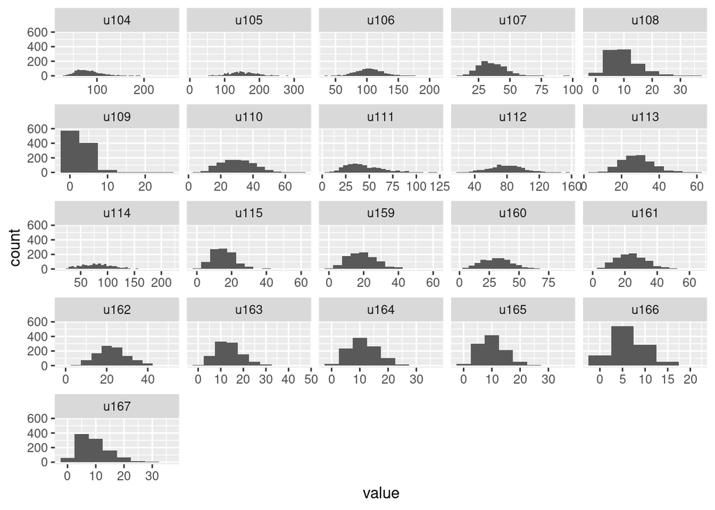

```r
par(mar=c(5,5,3,0)) ##This margin command should do the trick

explorData %>% gather() %>%
  ggplot2::ggplot(
    aes(
      x = value
    )
  )+
  ggplot2:: geom_histogram(binwidth = 5)  +
  facet_wrap(~key, scales = 'free_x')
```

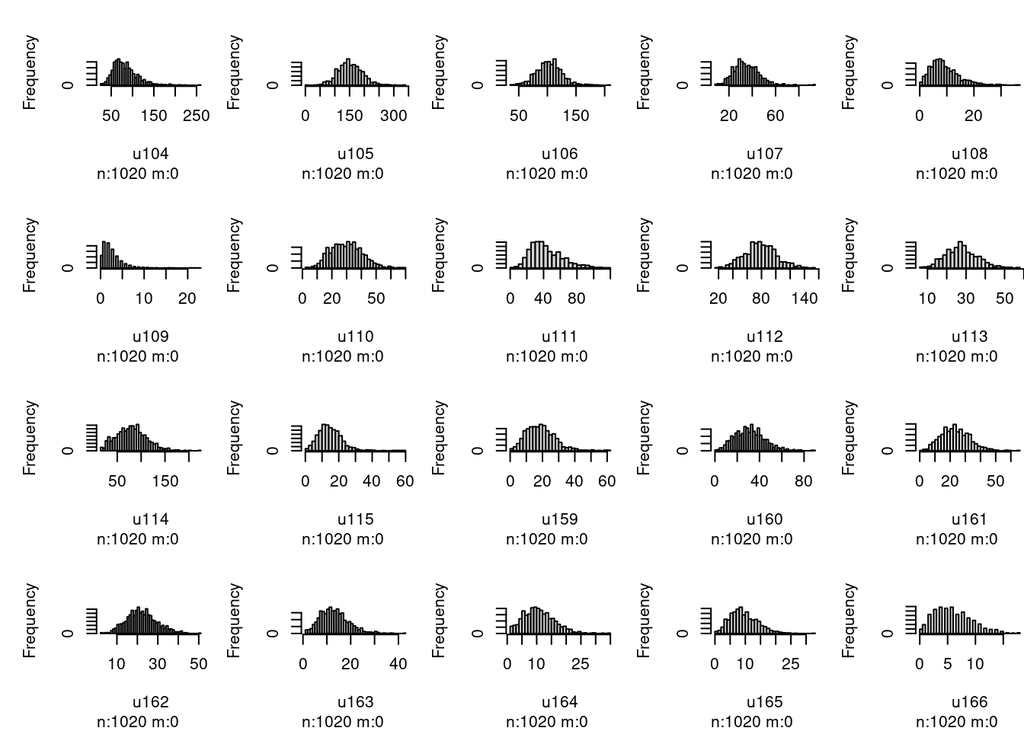

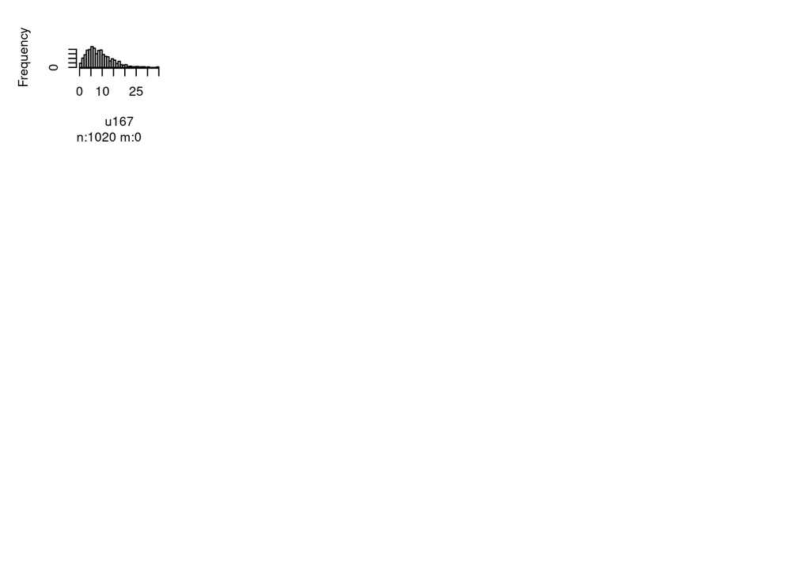

```r
hist.data.frame(explorData)
```

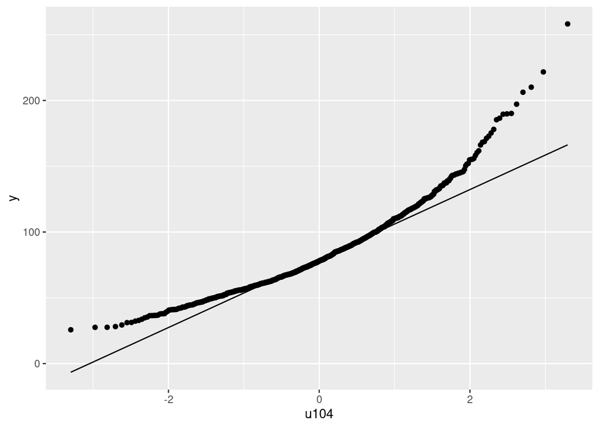

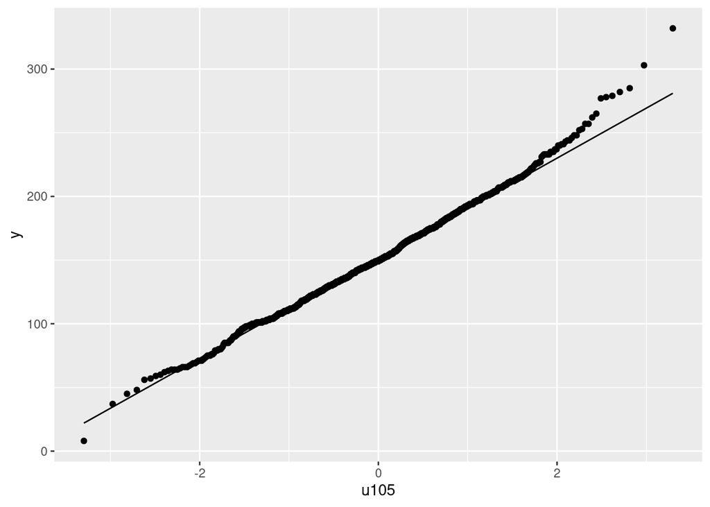

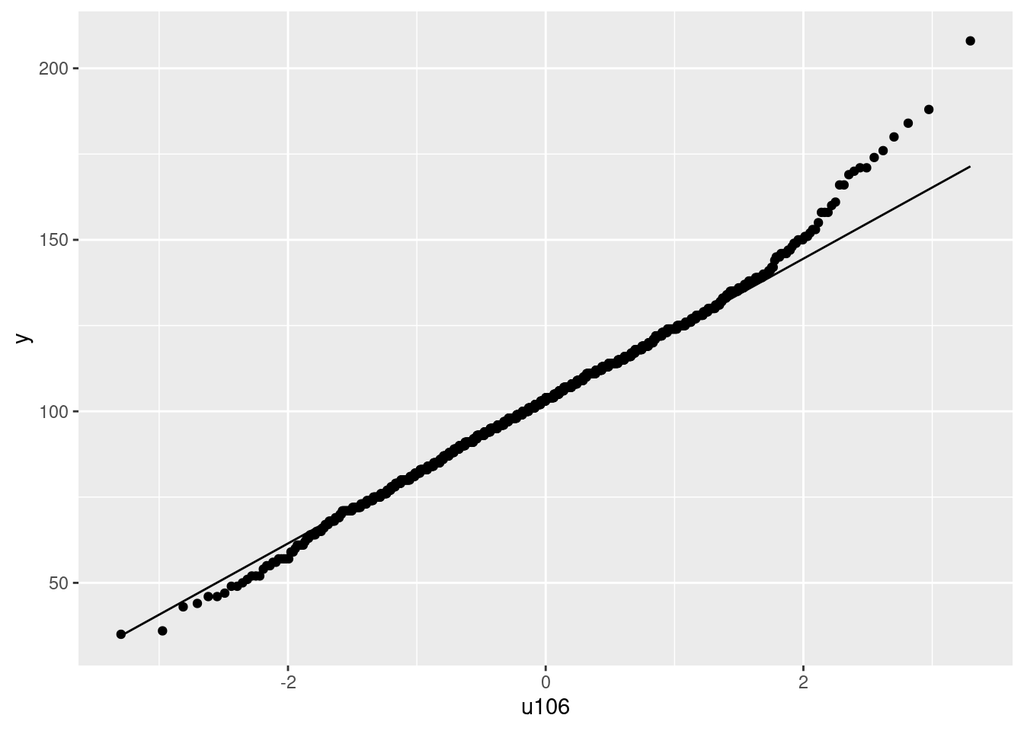

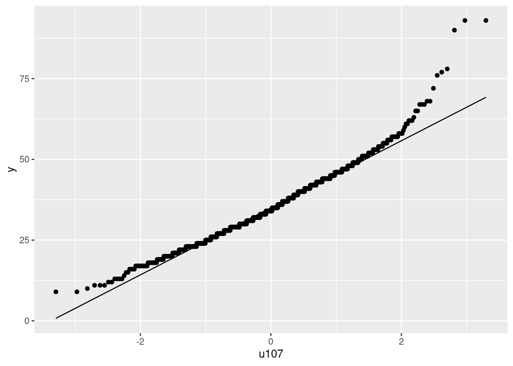

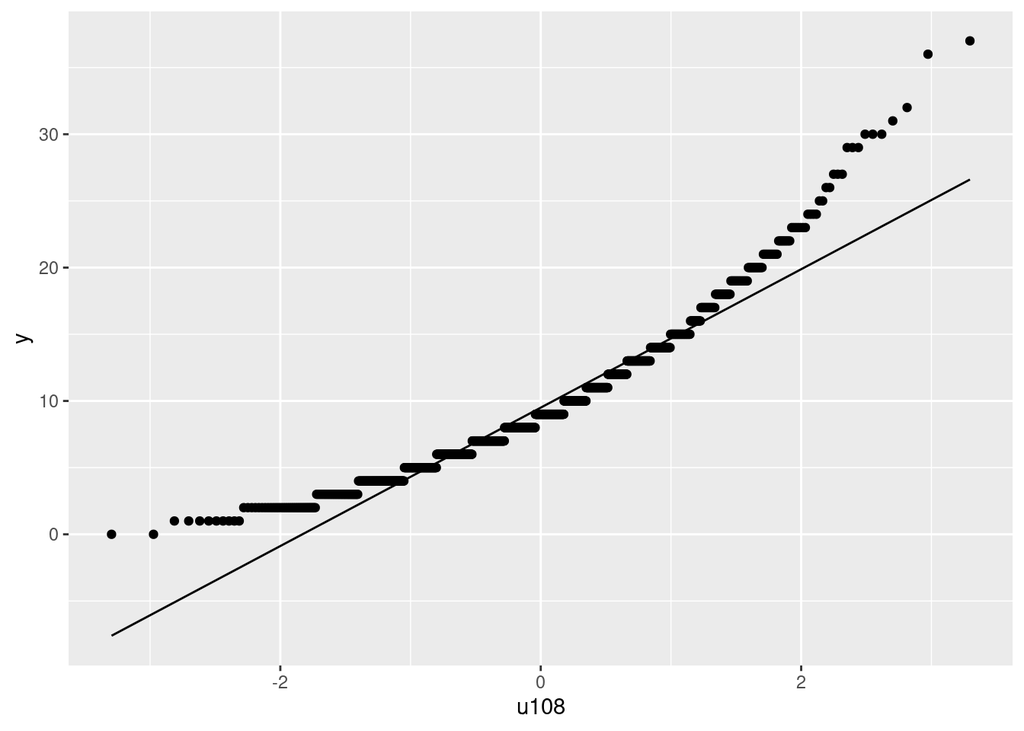

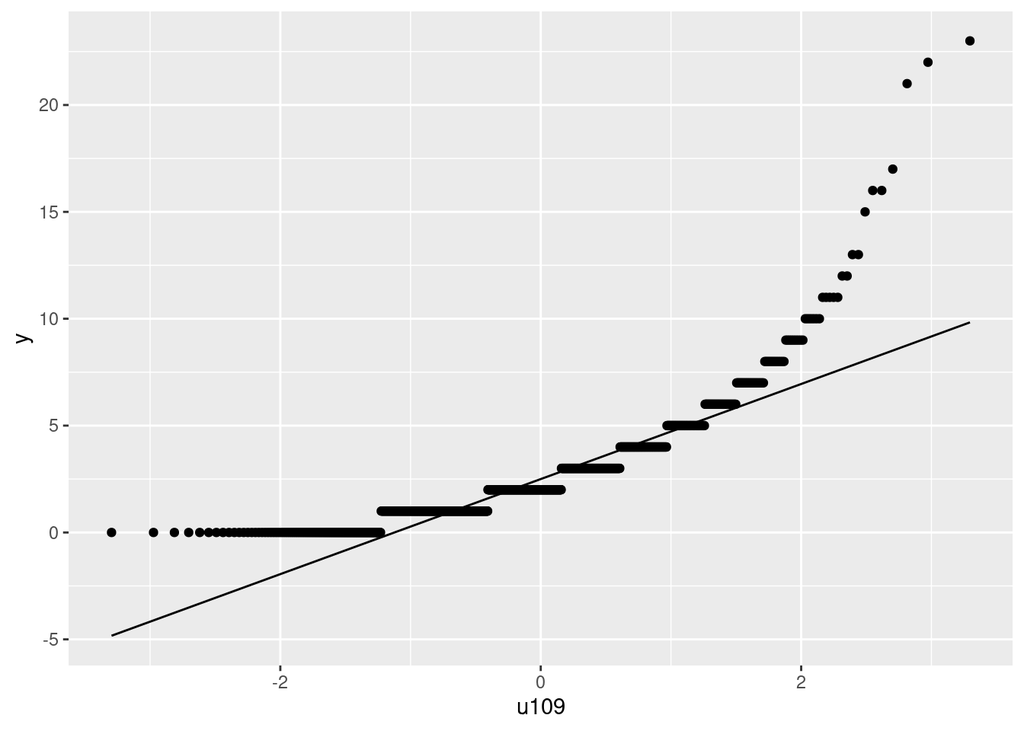

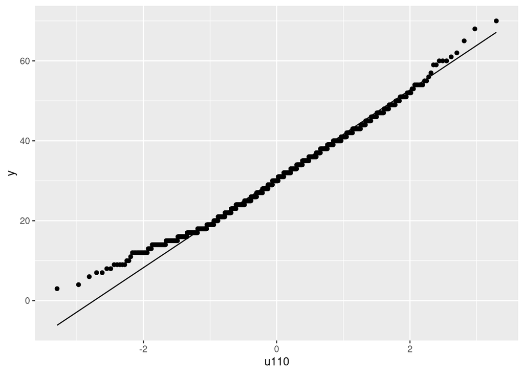

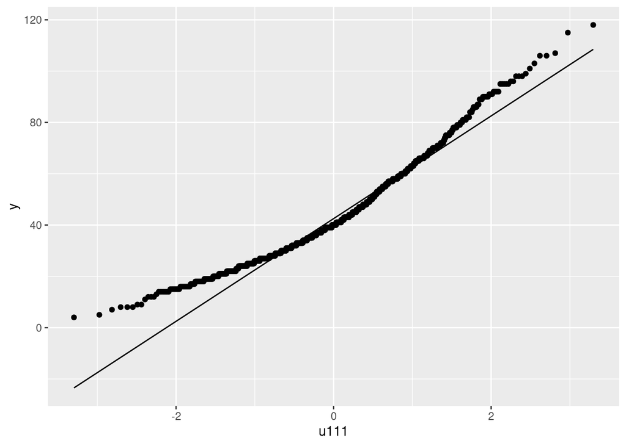

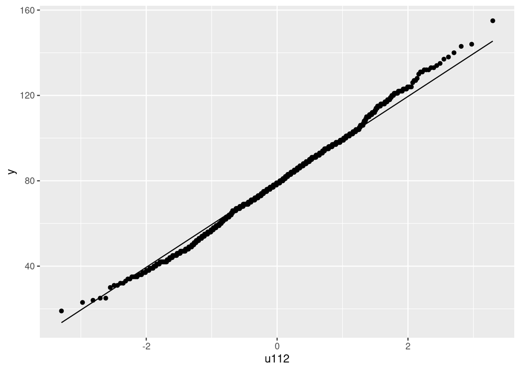

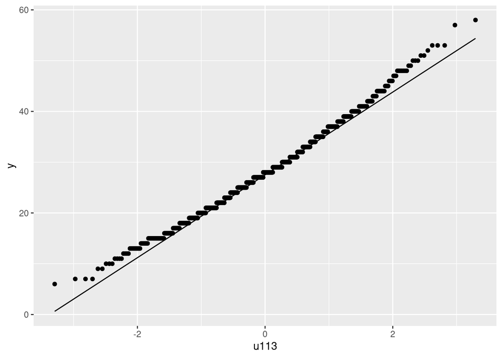

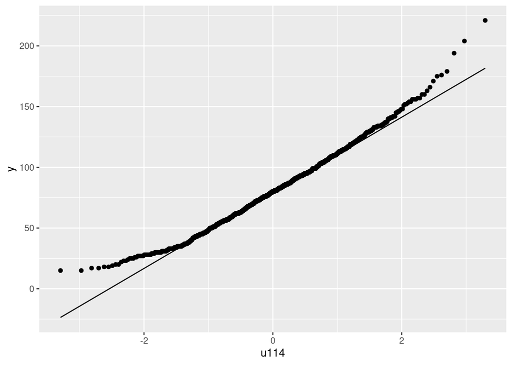

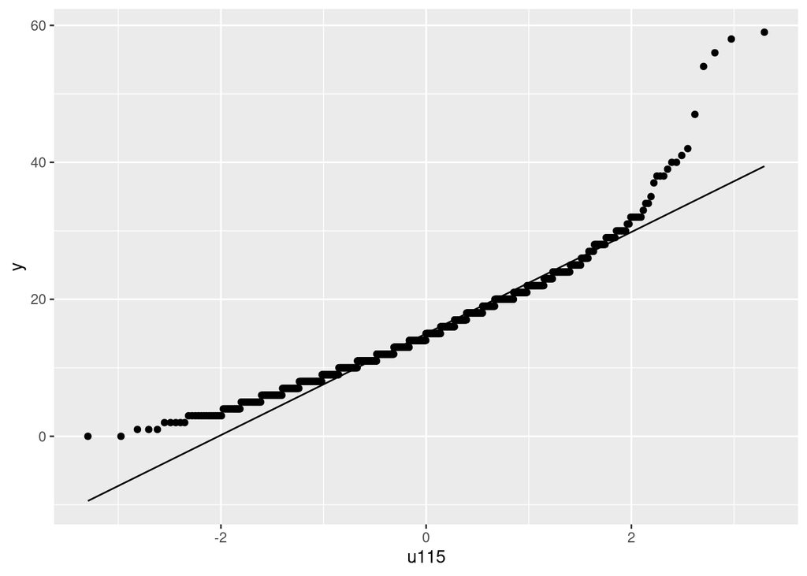

[9 more figures not shown]

```r
for (i in 1:ncol(explorData)) {
 plt <-  ggplot2::ggplot(explorData,
    aes(
      sample = explorData[,i]
    )
  ) +
    ggplot2::stat_qq() +
    ggplot2::stat_qq_line()+
   ggplot2::xlab(colnames( explorData[i]))
 print(plt)

}
```

The result from the histogram shows that non of the variables are perfectly normally distributed. However, variables `u112, u105, u106, u162` are close to being normally distributed.

### 1.13 Tranforming the data with Inverse hyperbolic sine function

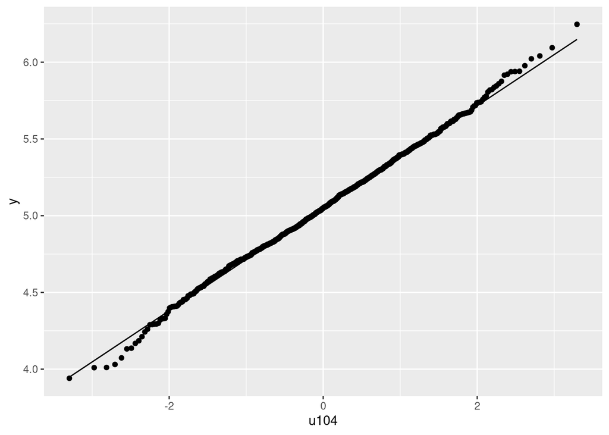

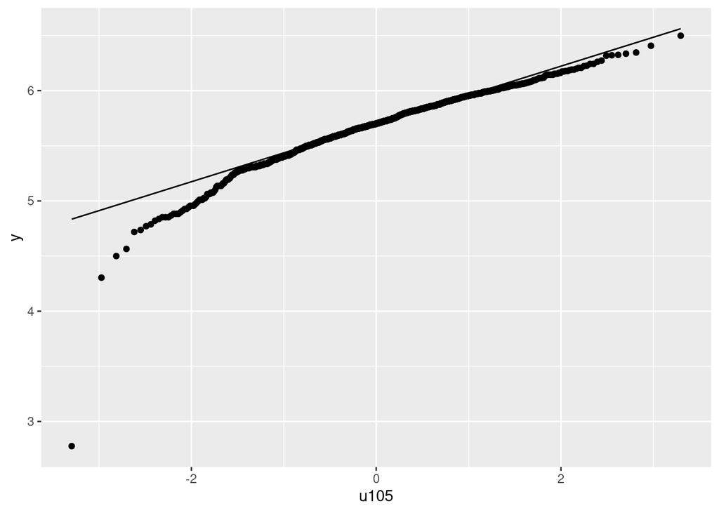

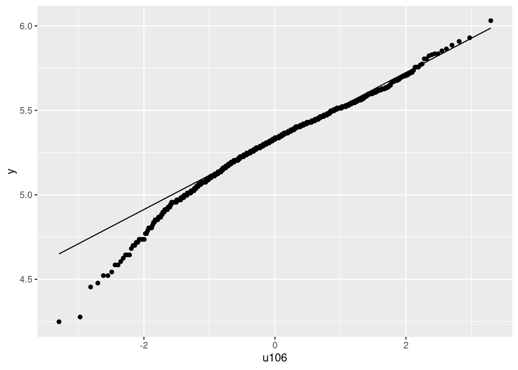

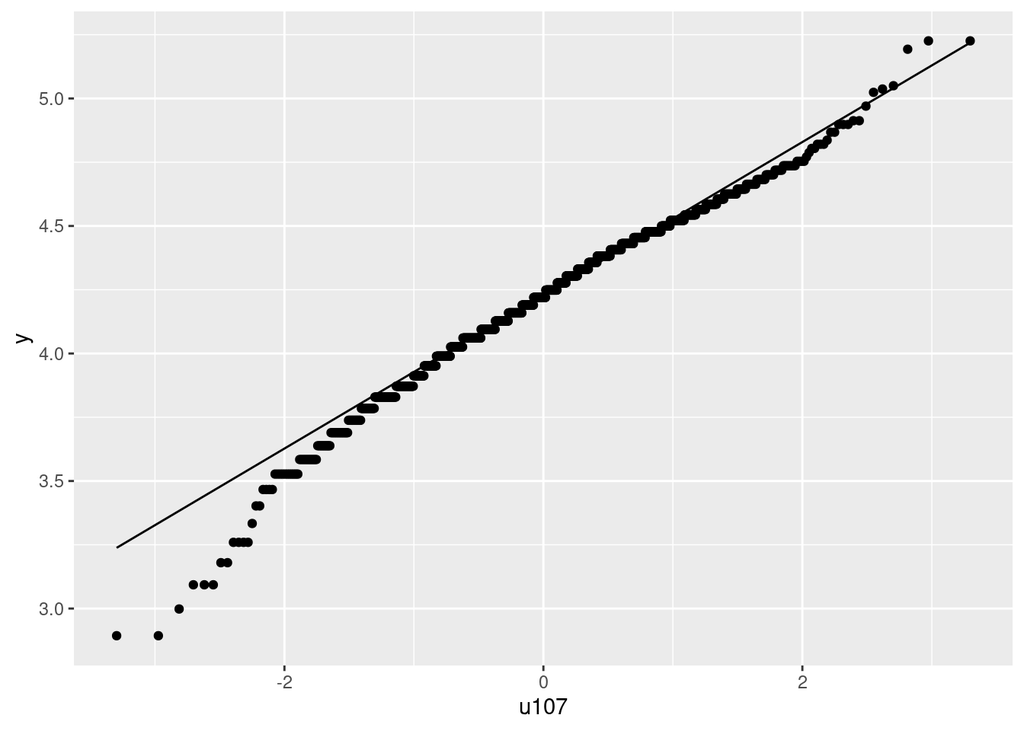

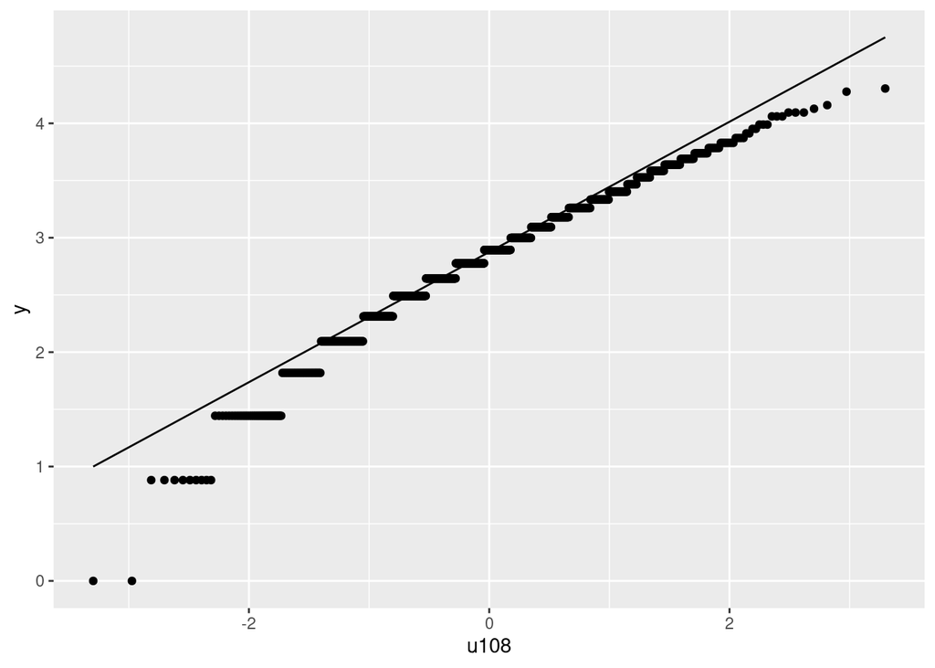

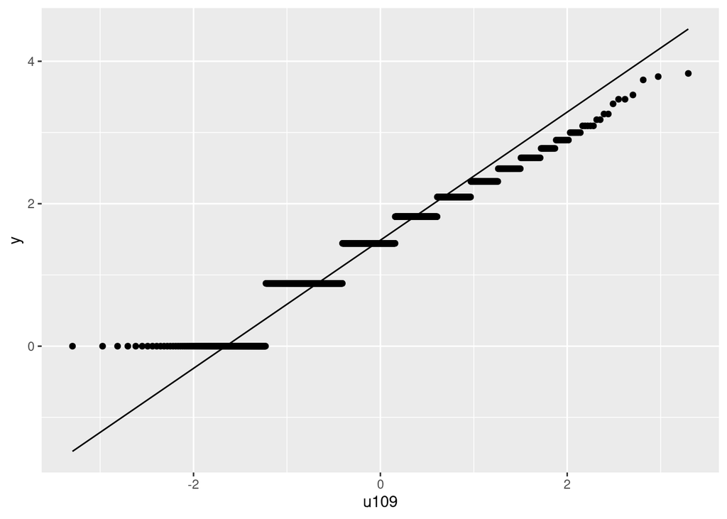

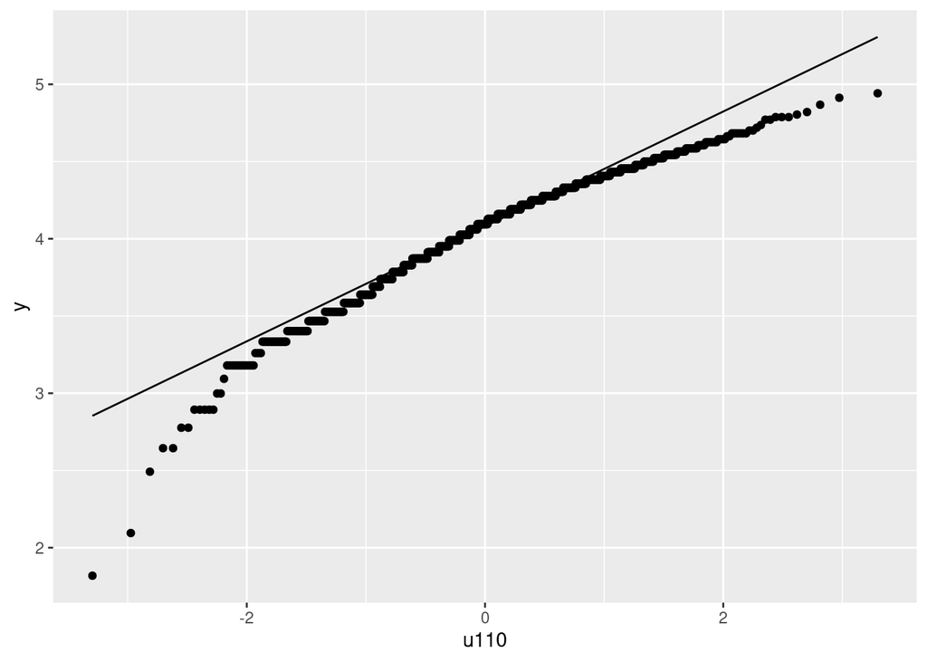

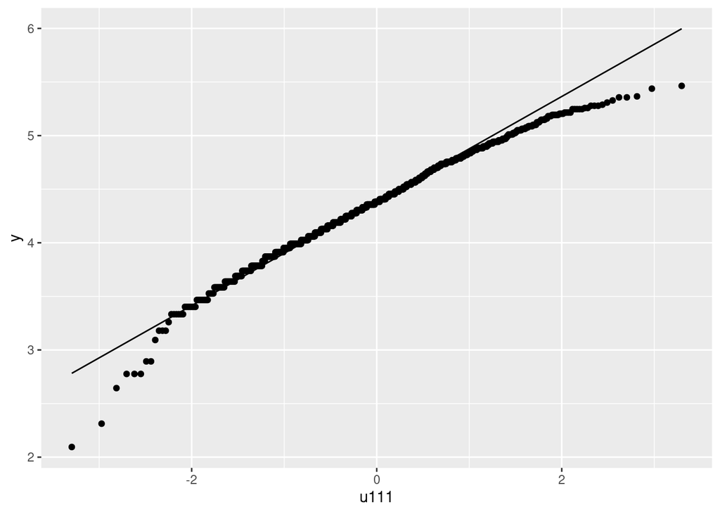

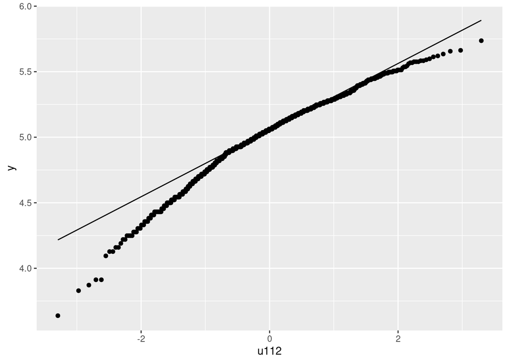

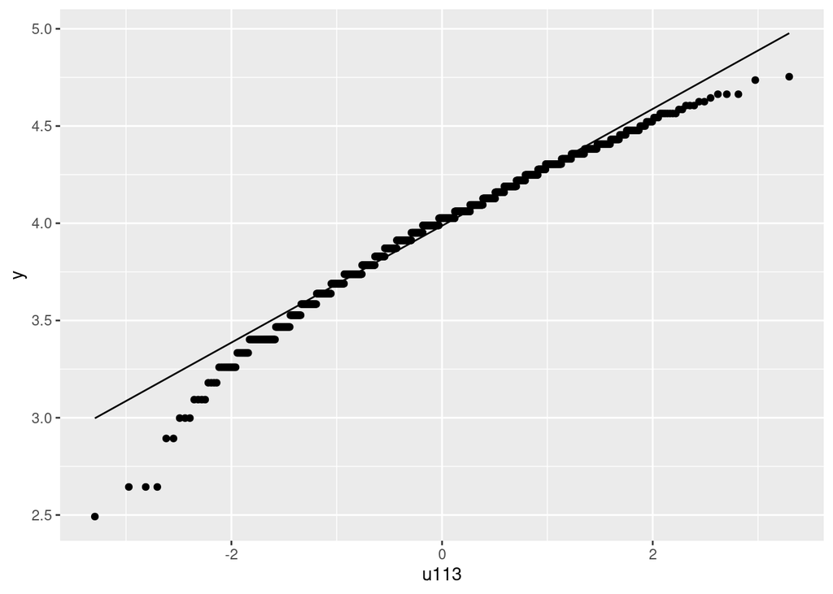

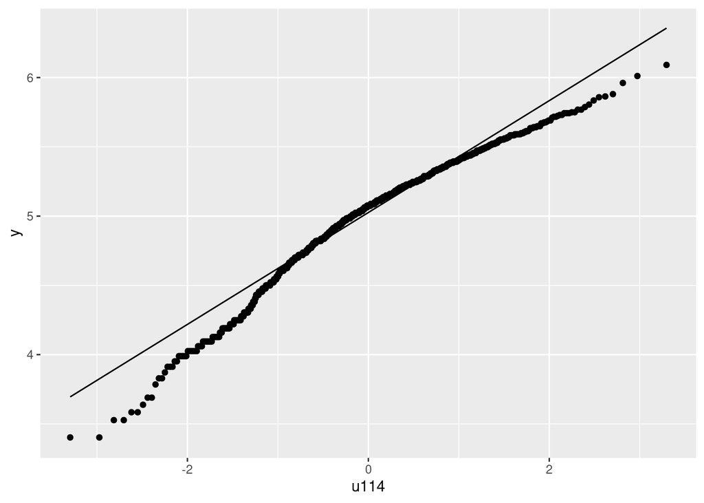

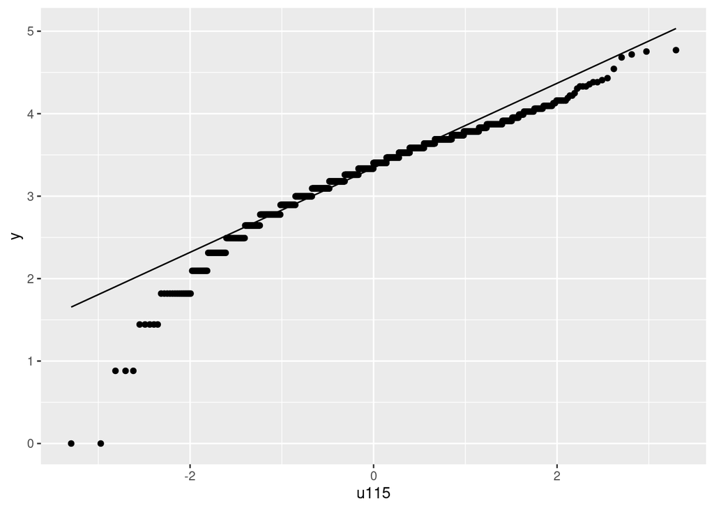

[9 more figures not shown]

```r
for (i in 1:ncol(explorData)) {
 plt <-  ggplot2::ggplot(explorData,
    aes(
      #adding inverse hyperbolic sine function
      sample = asinh(explorData[,i])
    )
  ) +
    ggplot2::stat_qq() +
    ggplot2::stat_qq_line()+
   ggplot2::xlab(colnames( explorData[i]))
 print(plt)

}
```

After transforming the transformed data (with inverse hyperbolic sine), the situation did not improve. Considering that plots are not the most accurate way of checking the normally of variables, we opted for statistical methods.

### 1.21 Statistical approach to exploratory analysis and descriptive statistics of the data

```r
stat_view <- explorData  %>%
  pastecs::stat.desc(norm = TRUE) %>%
  round(5)

print(stat_view)
```

```
##                     u104         u105         u106        u107       u108
## nbr.val       1020.00000   1020.00000   1020.00000  1020.00000 1020.00000
## nbr.null         0.00000      0.00000      0.00000     0.00000    2.00000
## nbr.na           0.00000      0.00000      0.00000     0.00000    0.00000
## min             25.70986      8.00000     35.00000     9.00000    0.00000
## max            258.17275    332.00000    208.00000    93.00000   37.00000
## range          232.46290    324.00000    173.00000    84.00000   37.00000
## sum          84522.47699 154998.00000 105574.00000 36098.00000 9904.00000
## median          77.94665    149.50000    103.50000    34.00000    9.00000
## mean            82.86517    151.95882    103.50392    35.39020    9.70980
## SE.mean          0.90878      1.27974      0.69948     0.34379    0.16941
## CI.mean.0.95     1.78329      2.51122      1.37259     0.67461    0.33243
## var            842.39926   1670.47917    499.06083   120.55221   29.27390
## std.dev         29.02412     40.87150     22.33967    10.97963    5.41054
## coef.var         0.35026      0.26896      0.21583     0.31024    0.55722
## skewness         1.22876      0.25581      0.26070     0.77408    1.18682
## skew.2SE         8.02227      1.67011      1.70207     5.05380    7.74847
## kurtosis         2.87710      0.51392      0.94996     2.03134    2.14862
## kurt.2SE         9.40112      1.67926      3.10406     6.63753    7.02077
## normtest.W       0.93275      0.99460      0.99108     0.96913    0.92668
## normtest.p       0.00000      0.00102      0.00001     0.00000    0.00000
##                    u109        u110        u111        u112        u113
## nbr.val      1020.00000  1020.00000  1020.00000  1020.00000  1020.00000
## nbr.null      112.00000     0.00000     0.00000     0.00000     0.00000
## nbr.na          0.00000     0.00000     0.00000     0.00000     0.00000
## min             0.00000     3.00000     4.00000    19.00000     6.00000
## max            23.00000    70.00000   118.00000   155.00000    58.00000
## range          23.00000    67.00000   114.00000   136.00000    52.00000
## sum          2818.00000 31012.00000 44572.00000 80656.00000 28644.00000
## median          2.00000    30.00000    40.00000    79.00000    28.00000
## mean            2.76275    30.40392    43.69804    79.07451    28.08235
## SE.mean         0.07969     0.32952     0.60058     0.67624     0.25776
## CI.mean.0.95    0.15638     0.64661     1.17852     1.32697     0.50580
## var             6.47751   110.75327   367.91266   466.43998    67.76750
## std.dev         2.54510    10.52394    19.18105    21.59722     8.23210
## coef.var        0.92122     0.34614     0.43895     0.27312     0.29314
## skewness        2.61363     0.30229     0.81435     0.14423     0.33283
## skew.2SE       17.06377     1.97356     5.31668     0.94164     2.17295
## kurtosis       12.47496    -0.06134     0.46615    -0.01207     0.16342
## kurt.2SE       40.76273    -0.20043     1.52318    -0.03943     0.53398
```

[output cut: 50 more lines]

```
## range          35.00000
## sum          9630.00000
## median          9.00000
## mean            9.44118
## SE.mean         0.17533
## CI.mean.0.95    0.34404
## var            31.35375
## std.dev         5.59944
## coef.var        0.59309
## skewness        1.07157
## skew.2SE        6.99601
## kurtosis        1.51475
## kurt.2SE        4.94956
## normtest.W      0.93272
## normtest.p      0.00000
```

Since the number of observation for each variable is greater than 1000, I chose 0.01 and the significance level.

`1.21` various statistics including the *mean, median, standard error, and more. We are more interested in the Skewness, skew.2SE, Kurtosis, kurt.2SE and normtest.p* value for each of the variables. According to the result of the statistics, the skewness and kurtosis for all the variables are not equal to zero; hence, they are not normally distributed. All the variables are positively skewed, hence, skewed to the right. Meanwhile, two variable `u110 (Provides unpaid care) and u112 ( Level 1, Level 2 or Apprenticeship)` have flat distribution according to the kurtosis result while the remaining are heavy tailed.

### 1.3 Kendall’s regression correlation plot

[figure not shown]

```r
corrplot(cor(explorData, method = "kendall"), type = "upper",
         tl.cex=0.5, method = 'shade', order = 'AOE',
         diag = FALSE,  tl.col="black")
```

Since we know that non of the variables are normally distributed and all the variables have duplication, according to `1.1` result, we cannot use Pearson and Spearman’s correlation, hence; hence we used the Kendall’s correlation The correlation plot for all the 21 variables. It was ordered in such a way to create cluster based on the correlation value. The negatively correlated variables are at the top right corner of the chart, (brown shaded color) while the uncorrelated are in the middle (white color), and the highly correlated variables fill the remaining place.

### 2.0 Part 2

### 2.11 Selecting the data needed for the regression analysis

```r
regression_data <- OwnLadd %>%
  select( Total_Population, u104:u115, u159:u167) %>%
#converting each column to represent percentage of population
  mutate(
    across(u104:u167,
           function(x){
             (x/Total_Population)*100
           })
  ) %>%
  #renaming the variables
  rename_with(
     function(x){paste('perc', x, sep = "_")},
     u104:u167
  )
```

### 2.12 Checking the normality of the variables after normalizing them with percentage population

```r
stat_view2 <- regression_data  %>%
  pastecs::stat.desc(norm = TRUE) %>%
  round(5)
print(stat_view2)
```

```
##              Total_Population   perc_u104   perc_u105   perc_u106   perc_u107
## nbr.val            1020.00000  1020.00000  1020.00000  1020.00000  1020.00000
## nbr.null              0.00000     0.00000     0.00000     0.00000     0.00000
## nbr.na                0.00000     0.00000     0.00000     0.00000     0.00000
## min                 112.00000     7.39814     5.19481    21.38728     4.50450
## max                 603.00000   167.64464    70.02519    45.78947    40.90909
## range               491.00000   160.24651    64.83038    24.40219    36.40459
## sum              309392.00000 29788.69613 50669.77192 34889.40043 12132.08690
## median              302.00000    25.94649    50.17012    34.00693    11.19796
## mean                303.32549    29.20460    49.67625    34.20529    11.89420
## SE.mean               1.89171     0.47653     0.21412     0.11934     0.12123
## CI.mean.0.95          3.71209     0.93509     0.42017     0.23418     0.23789
## var                3650.13144   231.62116    46.76486    14.52671    14.99033
## std.dev              60.41632    15.21910     6.83848     3.81139     3.87173
## coef.var              0.19918     0.52112     0.13766     0.11143     0.32551
## skewness              0.31654     2.67054    -0.64267     0.14847     1.48854
## skew.2SE              2.06664    17.43537    -4.19588     0.96931     9.71835
## kurtosis              1.64467    13.12420     1.79828    -0.06276     5.22833
## kurt.2SE              5.37406    42.88419     5.87598    -0.20507    17.08390
## normtest.W            0.98472     0.80166     0.97910     0.99700     0.91652
## normtest.p            0.00000     0.00000     0.00000     0.05181     0.00000
##               perc_u108  perc_u109   perc_u110   perc_u111   perc_u112
## nbr.val      1020.00000 1020.00000  1020.00000  1020.00000  1020.00000
## nbr.null        2.00000  112.00000     0.00000     0.00000     0.00000
## nbr.na          0.00000    0.00000     0.00000     0.00000     0.00000
## min             0.00000    0.00000     1.66667     3.40136    12.33766
## max            15.62500    7.14286    20.07299    69.48052    39.09348
## range          15.62500    7.14286    18.40633    66.07916    26.75582
## sum          3361.30067  947.44008 10176.50313 14962.90809 26473.80726
## median          2.88787    0.73801     9.81161    13.07403    26.00143
## mean            3.29539    0.92886     9.97696    14.66952    25.95471
## SE.mean         0.06036    0.02600     0.08725     0.20927     0.14173
## CI.mean.0.95    0.11844    0.05102     0.17122     0.41065     0.27812
## var             3.71595    0.68942     7.76568    44.67059    20.48995
## std.dev         1.92768    0.83031     2.78670     6.68361     4.52658
## coef.var        0.58496    0.89390     0.27931     0.45561     0.17440
## skewness        1.47157    2.17525     0.29734     1.42929     0.00103
## skew.2SE        9.60758   14.20170     1.94129     9.33150     0.00670
## kurtosis        4.02607    8.33497     0.16815     5.01967    -0.15503
## kurt.2SE       13.15543   27.23504     0.54945    16.40208    -0.50657
```

[output cut: 50 more lines]

```
## range          12.13389
## sum          3197.66947
## median          2.79070
## mean            3.13497
## SE.mean         0.05561
## CI.mean.0.95    0.10911
## var             3.15380
## std.dev         1.77589
## coef.var        0.56648
## skewness        0.89427
## skew.2SE        5.83847
## kurtosis        0.81193
## kurt.2SE        2.65303
## normtest.W      0.94818
## normtest.p      0.00000
```

### 2.13 Selecting the variable to be used for the regression analysis

How main focus is to check the relationship between variable `perc_u106` (percentage of people with good Health), `perc_u112`(percentage of people with Level 1, Level 2 or Apprenticeship qualifications) and `perc_u162`(percentage of people with Administrative and secretarial occupations). The two independent variables `perc_u112 and perc_u162`were chosen because they are normally distributed and they are likely uncorrelated.

```r
forregression <- regression_data %>%
  select(perc_u106, perc_u112, perc_u162)
```

Since the three variables `perc_u106`(percentage of people with good health), `perc_u112` (percentage of people with Level 1, Level 2 or Apprenticeship qualifications) and `perc_u162` () meet the assumptions of Pearson correlation, we will run a pearson correlation

### 2.21 Pearson correlation between variable perc_u106 and perc_u112

```r
forregression %$%
cor.test(perc_u106, perc_u112)
```

```
##
##  Pearson's product-moment correlation
##
## data:  perc_u106 and perc_u112
## t = 3.6591, df = 1018, p-value = 0.0002661
## alternative hypothesis: true correlation is not equal to 0
## 95 percent confidence interval:
##  0.05292495 0.17410127
## sample estimates:
##       cor
## 0.1139368
```

### 2.22 Pearson regression between variables perc_u106 and perc_u162

```r
forregression %$%
  cor.test( perc_u106, perc_u162)
```

```
##
##  Pearson's product-moment correlation
##
## data:  perc_u106 and perc_u162
## t = 3.5233, df = 1018, p-value = 0.0004451
## alternative hypothesis: true correlation is not equal to 0
## 95 percent confidence interval:
##  0.04870619 0.16999679
## sample estimates:
##       cor
## 0.1097601
```

`2.22` shows the result of the correlation between the percentage of people with good health and the percentage of people with Administrative and secretarial occupations. According to the result, we reject the null hypothesis that there is no correlation between the two variables `perc_u106 and perc_u162` since the p-value is less than 0.01; hence, there is relationship between the two varialble. The correlation is positive since the `cor` value is **0.1097601**. However, the correlation is very weak as the two variables share only **1.2% variability**.

```r
health_model <- forregression %$%
  lm(perc_u106 ~ perc_u112 + perc_u162)
```

#2.32 Summary of the model

```r
summary(health_model)
```

```
##
## Call:
## lm(formula = perc_u106 ~ perc_u112 + perc_u162)
##
## Residuals:
##      Min       1Q   Median       3Q      Max
## -11.8891  -2.5656  -0.2614   2.5220  11.5524
##
## Coefficients:
##             Estimate Std. Error t value Pr(>|t|)
## (Intercept) 30.79670    0.75456  40.814  < 2e-16 ***
## perc_u112    0.08282    0.02649   3.126  0.00182 **
## perc_u162    0.16799    0.05662   2.967  0.00308 **
## ---
## Signif. codes:  0 '***' 0.001 '**' 0.01 '*' 0.05 '.' 0.1 ' ' 1
##
## Residual standard error: 3.774 on 1017 degrees of freedom
## Multiple R-squared:  0.02145,    Adjusted R-squared:  0.01953
## F-statistic: 11.15 on 2 and 1017 DF,  p-value: 1.625e-05
```

The summary of the model indicates that:

- The p-value is **0.00001625: p-value < 0.01**; Hence the model is significant. We can reject the null hypothesis that none of the predictors have relationship with the response variable.
  - This result is gotten by comparing the `F-statistic to F distribution` **11.15** where the `degrees of freedom` is **(2, 1017)**
  - F (2, 1017) = **11.15**
  - Adjusted R-squared = **0.01953**
- Coefficient
  - the coefficient = **30.79670 (significant)**
  - The coefficient of slope for % of people with with `Level 1, Level 2 or Apprenticeship qualifications` is estimated as **0.08282 (significant)**
  - The coefficient of slope for % of people with with `Administrative and secretarial occupations` is estimated as **0.16799 (Significant)**

### 2.4 Test for normality, homoscedasticity, independence and multocollinearity

```r
# 2.41 Test for normality
health_model %>%
  stats::rstandard() %>%
  stats::shapiro.test()
```

```
##
##  Shapiro-Wilk normality test
##
## data:  .
## W = 0.99633, p-value = 0.01678
```

```r
# 2.42 Test for homoscedasticity
health_model %>%
  lmtest::bptest()
```

```
##
##  studentized Breusch-Pagan test
##
## data:  .
## BP = 1.7153, df = 2, p-value = 0.4242
```

```r
# 2.43 Test for independence
health_model %>%
  lmtest::dwtest()
```

```
##
##  Durbin-Watson test
##
## data:  .
## DW = 1.9789, p-value = 0.3613
## alternative hypothesis: true autocorrelation is greater than 0
```

```r
# 2.43 Test for multocollinearity
health_model %>%
  vif()
```

```
## perc_u112 perc_u162
##  1.028645  1.028645
```

The output of the model indicates that the model fits **(F (2, 1017) = 11.15), p-Value < 0.01**. However, the model on the percentage of people with `Level 1, Level 2 or Apprenticeship qualifications` and people with `Administrative and secretarial occupations` can only predict **2%** of people with `good health`. The model have normally distributed residuals **(Shapiro-Wilk test, W=0.99, p=0.01678)**, no multicollinearity with average **VIF 1.028645**, the residuals satisfy the assumption of homoscedasticity **(Breusch-Pagan test, BP = 1.7153, p-value = 0.4242)** and assumptions of independence **(Durbin-Watson test, DW = 1.9789, p-value = 0.3613)**, However, we can say that the model is partially robust because of the low adjusted R-squared value. Based on the result, the model indicates that for every one percent increase in the percentage of people with with `Level 1, Level 2 or Apprenticeship qualifications`, there will be **0.08282** increase in the percentage of people with `good health`. Similarly, for every one percent increase in the percentage of people with `Administrative and secretarial occupations`, there will be **0.16799** increase in the percentage of people with `good health`.

### 2.51 Residual vs Fitted plot

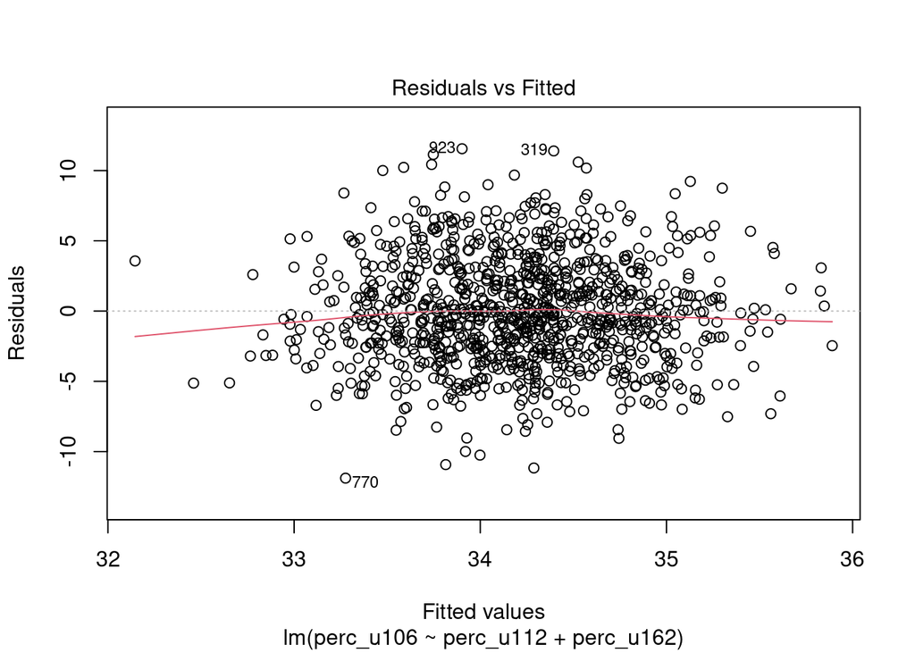

```r
health_model %>%
  plot(which = c(1))
```

`2.51` gives an insight into the `homoskedasticity` of the residual. Since the red line is close to the dash line, the linearity of the model seems to hold well, the model is `homoskedastic` as the variance is not increasing, and point `770, 923 and 319` are outliers.

### 2.52 Normal Q-Q plot

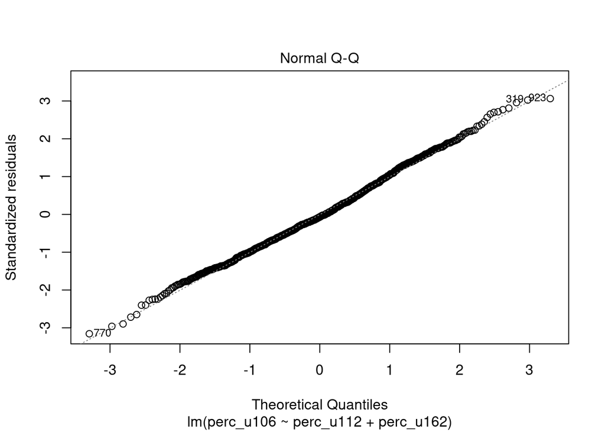

```r
health_model %>%
  plot(which = c(2))
```

`2.52` shows the normality of the residuals. The fact that the qq plot lies on the line shows that it is normally distributed.

### 2.53 Residual vs Leverage plot

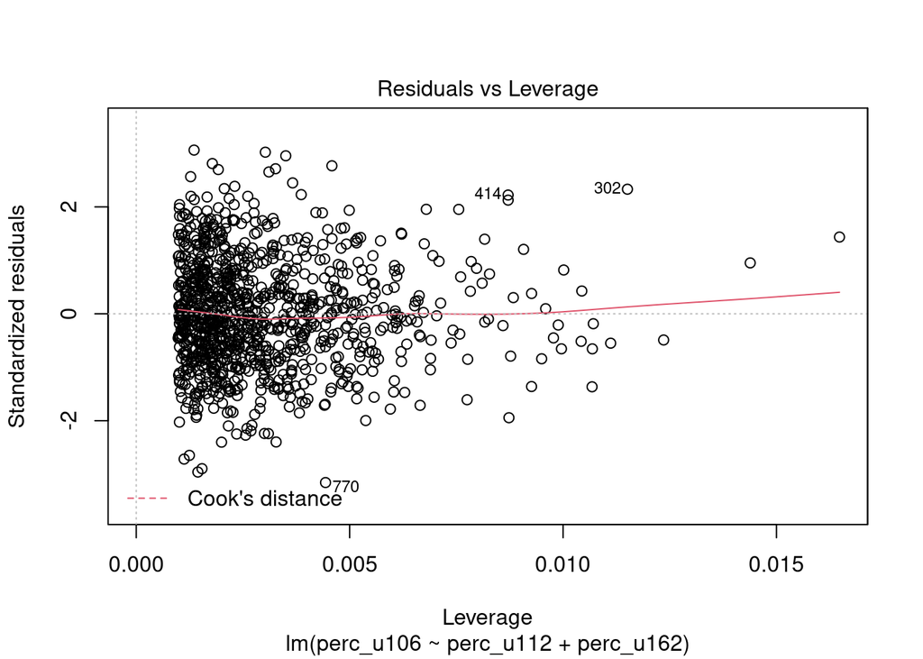

```r
health_model %>%
  plot(which = c(5))
```

`2.53` gives insight about the `Cook's distance`. No point fall outside the `Cook's Distance`, indicating that there is no influential point in the regression model.

### Part 3

### 3.1

Thanks to the classes we had in the first and second part of this course, I was able to achieve this task with not so much difficulty. As suggested in the course, I first observed and visualize my data to understand the types of data I have using key functions like `describe(), str(), stat.desc(), histogram, ggplot and qqplot`. I also tried to observe the relationship between the variables with correlation analysis before running a regression model. Afterwards, I tried to check the robusteness of my model with functions like `shapiro.test(), vif(), bptest(), dwtest()` and more . All these helped me to achieve the task. We with known I had in the first part, the data predictability was quite straight forward with libraries like `dplyr, magrittr, tidyverse` and more.

## Reference

1. Sthda.com. 2022. Correlation matrix : A quick start guide to analyze, format and visualize a correlation matrix using R software - Easy Guides - Wiki - STHDA. [online] Available at: http://www.sthda.com/english/wiki/correlation-matrix-a-quick-start-guide-to-analyze-format-and-visualize-a-correlation-matrix-using-r-software [Accessed 6 January 2022].
2. Rdocumentation.org. 2022. describe function - RDocumentation. [online] Available at: https://www.rdocumentation.org/packages/Hmisc/versions/4.6-0/topics/describe [Accessed 6 January 2022].
3. Medium. 2022. How to Create a Correlation Matrix with Too Many Variables in R. [online] Available at: https://towardsdatascience.com/how-to-create-a-correlation-matrix-with-too-many-variables-309cc0c0a57 [Accessed 6 January 2022].
4. Boostedml. 2022. Linear Regression Plots: Fitted vs Residuals - Boostedml. [online] Available at: https://boostedml.com/2019/03/linear-regression-plots-fitted-vs-residuals.html [Accessed 6 January 2022].
5. Sabbata, S., 2022. Chapter 8 Regression analysis | R for Geographic Data Science. [online] Sdesabbata.github.io. Available at: https://sdesabbata.github.io/r-for-geographic-data-science/regression-analysis.html [Accessed 6 January 2022].

## Appendix

1. This document includes information from public sector licensed under the Open Government Licence v3.0 from the Office for National Statistics.
2. **VariableCode** | **VariableDescription**  
   u104: | Day-to-day activities limited a lot or a little Standardised Illness Ratio  
   u105: | Very good health  
   u106: | Good health  
   u107: | Fair health  
   u108: | Bad health  
   u109: | Very bad health  
   u110: | Provides unpaid care  
   u111: | No qualifications  
   u112: | Highest level of qualification: Level 1, Level 2 or Apprenticeship  
   u113: | Highest level of qualification: Level 3 qualifications  
   u114: | Highest level of qualification: Level 4 qualifications and above  
   u115: | Schoolchildren and full-time students: Age 16 and over  
   u159: | Managers, directors and senior officials  
   u160: | Professional occupations  
   u161: | Associate professional and technical occupations  
   u162: | Administrative and secretarial occupations  
   u163: | Skilled trades occupations  
   u164: | Caring, leisure and other service occupations  
   u165: | Sales and customer service occupations  
   u166: | Process, plant and machine operatives  
   u167: | Elementary occupations